# 21-01 주제분석 3주차 패키지

```python
import pandas as pd
import numpy as np

import matplotlib.pyplot as plt
import seaborn as sns

from category_encoders.cat_boost import CatBoostEncoder
import lightgbm as lgb
from lightgbm import LGBMModel,LGBMRegressor
```

```python
train = pd.read_csv('C:/Users/paa04/OneDrive/바탕 화면/P-SAT/21-1/데마/주제분석/3주차패키지/train.csv')
test=  pd.read_csv('C:/Users/paa04/OneDrive/바탕 화면/P-SAT/21-1/데마/주제분석/3주차패키지/test.csv')

train_x = train.drop(['price'], axis = 1)
train_y = train.loc[:, ['price']]
test_x = test.drop(['price'], axis = 1)
test_y = np.sqrt(test.loc[:, ['price']])

feature_list = list(train_x.columns)

CBE_encoder = CatBoostEncoder()
train_cbe = CBE_encoder.fit_transform(train_x[feature_list], train_y)
test_cbe = CBE_encoder.transform(test_x[feature_list])

best_lgbm_reg = LGBMRegressor(learning_rate = 0.3)
best_lgbm_reg.fit(train_cbe, train_y)
```

```
LGBMRegressor(learning_rate=0.3)
```

```python
feature_list
```

```
['dong',
 'apt',
 'exclusive_use_area',
 'floor',
 'transaction_year',
 'until_trans',
 'sin_date',
 'cos_date']
```

## 1.Interpretable ML

해석가능한 머신러닝은 모델의 결과를 해석하기 위한 방법들입니다. 보통 랜덤포레스트(Random Forest)에서 Feature(Variable) Importance에 대해 들어본 적이 있을텐데, 그것과 유사합니다. Interpretable ML 방법의 특징은 어떤 모델에도 다 적용이 가능하다는건데, SVM이나 Neural Net같이 해석이 불가능하다고 알려진 모델들도 어떤 변수들이 모델을 만드는데 있어서 주요하게 사용되었는지를 파악할 수 있게 해줍니다. 물론 회귀분석처럼 '다른 변수들을 고정시킨 상황에서 x 1 이 한단위 증가하면 y 가 평균적으로 β 1 만큼 증가한다' 라고 말할수는 없지만요!

Feature Importance/Partial Dependence Plot/Lime/SHAP 에 대한 해석은 조금 조심해야할 필요가 있습니다. 밑의 링크의 '모델해석 및 이탈원인 분석'을 참고하면 되는데, 처음에 딱 이해하기 쉬운 개념은 아니지만 나중에 보다보면 더 이해가 잘 되실 것 같아요.

https://danbi-ncsoft.github.io/competition/2019/02/19/big-contest-2018-retrospect.html

나중에 관심있으시면 이 책을 보는 것을 추천드립니다. 저도 아직 안봄 ㅎ

https://christophm.github.io/interpretable-ml-book/

### 1.1 모델 불러오기

```python
import pickle
import joblib
```

```python
with open('C:/Users/paa04/OneDrive/바탕 화면/P-SAT/21-1/데마/주제분석/3주차패키지/lgbm.pkl','rb') as f:
    model = pickle.load(f)
```

```python
model
```

```
LGBMRegressor(learning_rate=0.3)
```

### 1.2 Feature Importance 확인과 해석

- 불러온 모델에 대해 plot_importance함수를 통해 Feature Importance를 시각화해주세요.
- 결과에 대해 간단히 해석해주세요. 여기서 Feature Importance는 Permutation를 통한 중요도를 보는 것이 아니고, tree 모델 자체의 구성에서 어떤 변수가 지니불순도를 잘 줄였는지를 확인한 것이라고 이해해주시면 됩니다.

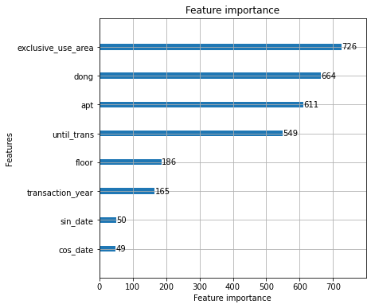

```python
from lightgbm import plot_importance

fig, ax = plt.subplots(figsize=(6,6))
plot_importance(model, max_num_features=15, ax=ax)
```

### 1.3 Randomness Control

- random, numpy 패키지의 난수를 42로 고정하세요.
- 더불어서 os 패키지의 난수도 고정해야합니다. Permutation 방식의 Feature Importance를 시행한건데, permutation자체에 랜덤성이 있다보니 결과가 재현 가능하도록 시드를 고정해줍니다.

파이썬의 시드 고정은 R처럼 그냥 set.seed()한다고 해서 고정되지 않습니다. 전체 파이썬과 여러 패키지들의 randomness를 각각 고정해주어야 재현가능해집니다. 정말 귀찮고, 딥러닝의 경우 GPU를 사용할 경우 GPU의 계산과 관련된 시드를 고정하면 속도가 상당히 느려진다고 알려져 있습니다. 더불어서 재현도 100%되진 않으며 성능도 살짝 떨어진다고는 하지만, GPU를 사용하지 않는 경우에는 문제가 없고 최소한 할줄은 알아야겠죠?

더불어서 왜 저런식으로 복잡하게 구성이 되는가?에 대해 궁금할 수 있는데 찾아본 적은 없지만 아마도 numpy는 c++가 뒤에서 연산을 해주는 것으로 알고있고(그래서 빠름!), random은 그냥 파이썬이고, os는 우리 os를 건드리는 것이 아닐까....? 추측입니다 :)

```python
import random
import os
```

```python
np.random.seed(42)
random.seed(42)
os.environ['PYTHONHASHSEED']=str(42)
```

### 1.4 Permutation Feature Importance

- permutation feature importance를 계산하기 위해 best_lgbm_reg를 permutation_importance함수를 사용해 test set에 적합하세요.
- permutation feature importance를 시각화해주세요. 위의 1.2에서는 train에서 변수중요도를 보고, 지금은 test에서 봐서 좀 이상하다고 생각할수도 있습니다. 편의를 위해, 그리고 실제로 변수중요도에 대한 부분에서 어떤 set에 대해 봐야하는지가 100% 정답처럼 있는 것은 아니라고 알고 있어요.(물론 제가 틀렸을수도!) 아무튼 너무 신경쓰지말고 해주세요!

```python
from sklearn.inspection import permutation_importance
perm = permutation_importance(best_lgbm_reg,test_cbe, test_y, random_state=42)
```

```python
perm.importances[7]
# perm.importances_mean로 시각화..?튜라이
```

```
array([777.32993619, 960.86844498, 764.74354336, 829.87832071,
       763.13005153])
```

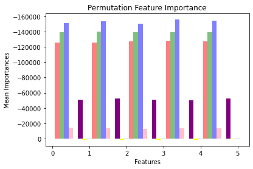

```python
X = np.arange(5)
plt.bar(X+0.125, perm.importances[0],color='r', width=0.125, alpha=0.5)
plt.bar(X+0.25, perm.importances[1],color='g', width=0.125, alpha=0.5)
plt.bar(X+0.375, perm.importances[2], color='b', width=0.125, alpha=0.5)
plt.bar(X+0.5, perm.importances[3],color='pink',width=0.125)
plt.bar(X+0.625, perm.importances[4], color='orange', width=0.125)
plt.bar(X+0.75, perm.importances[5],color='purple',width=0.125)
plt.bar(X+0.875, perm.importances[6], color='yellow',width=0.125)
plt.bar(X+1, perm.importances[7], color='skyblue', width=0.125)
plt.gca().invert_yaxis()
plt.title('Permutation Feature Importance')
plt.ylabel('Mean Importances')
plt.xlabel('Features')
plt.show()
```

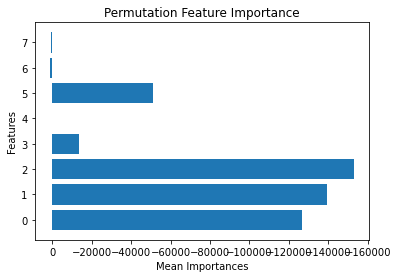

```python
plt.barh(range(len(perm.importances_mean)),perm.importances_mean)
plt.title('Permutation Feature Importance')
plt.xlabel('Mean Importances')
plt.ylabel('Features')
plt.gca().invert_xaxis()

plt.show()
```

### 1.5 SHAP(SHapley Additive exPlanations)의 확인과 해석

- shap.TreeExplainer, shap_values, shap.summary_plot 을 사용해 SHAP Value를 구하고 간단한 해석

```python
#!pip install shap
```

```python
import shap
```

```python
explainer = shap.TreeExplainer(best_lgbm_reg)
shap_values = explainer.shap_values(test_cbe)
```

```python
shap.initjs()
shap.force_plot(explainer.expected_value, shap_values[1,:], test_cbe.iloc[1,:])
```

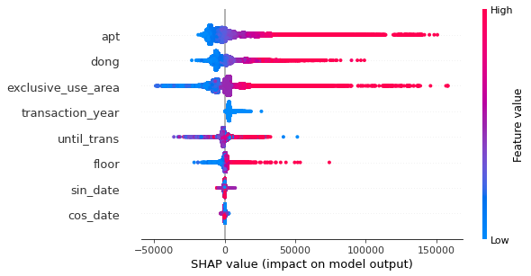

```python
shap.summary_plot(shap_values, test_cbe)
```

- apt, dong, exclusice_use_area, until_trans, floor: 변수의 값이 높을수록 예상 가경이 높은 경향성이 있다.
- transaction_year : 변수의 값이 낮을 수록, 예상 가격이 높은 경향성이 있다.
- sin_date, cos_date : 해석 모호성(Feature Value에 따른 Shap Values의 상관성 파악 모호)

## 2. 딥러닝 기본

딥러닝 정말 간단히 해볼겁니다!

### 2.1 주어진 코드를 실행하고, 현재 신경망의 구조에 대해 간단히 설명해 주세요.

```python
train = pd.read_csv('C:/Users/paa04/OneDrive/바탕 화면/P-SAT/21-1/데마/주제분석/3주차패키지/train.csv')
train_x = train.drop(['price'], axis = 1)
train_y = train.loc[:, ['price']]

val_x = train_x[train['transaction_year'] == 4]
val_y = train_y[train['transaction_year'] == 4]
train_tune_x = train_x[train['transaction_year'] < 4]
train_tune_y = train_y[train['transaction_year'] < 4]

CBE_encoder = CatBoostEncoder()
train_tune_cbe = CBE_encoder.fit_transform(train_tune_x[feature_list], train_tune_y)
val_cbe = CBE_encoder.transform(val_x[feature_list])
```

```python
import tensorflow as tf
import keras

from keras import models
from keras import layers
from keras.layers import Dense
from keras.optimizers import Adam
```

```python
def build_model():
  model = keras.Sequential([
    layers.Dense(256, activation='relu', input_shape=[len(train_tune_cbe.keys())]),
    layers.Dense(64, activation='relu'),
    layers.Dense(32, activation='relu'),
    layers.Dense(1)
  ])

  optimizer = tf.keras.optimizers.RMSprop(0.0001)

  model.compile(loss='mse',
                optimizer=optimizer,
                metrics=['mse'])
  return model
```

```python
model = build_model()
model.summary()
```

```
Model: "sequential"
_________________________________________________________________
Layer (type)                 Output Shape              Param #
=================================================================
dense (Dense)                (None, 256)               2304
_________________________________________________________________
dense_1 (Dense)              (None, 64)                16448
_________________________________________________________________
dense_2 (Dense)              (None, 32)                2080
_________________________________________________________________
dense_3 (Dense)              (None, 1)                 33
=================================================================
Total params: 20,865
Trainable params: 20,865
Non-trainable params: 0
_________________________________________________________________
```

모두 활성화 함수는 relu이고, 첫번째 layer는 256개의 node로 이루어져 있고 이를 통과하고 나서 통과하게 될 2번째 layer는 64개의 node로 3번째 layer는 32개의 node로 이루어져 있으며 이 모든 은닉층을 통과하고 나서 output layer에 통과가 되면 하나의 값으로 나오게 되는 형태의 신경망을 띄고 있다.

### 2.2 training loss 와 validation loss를 시각화

```python
history = model.fit(train_tune_cbe, train_tune_y, epochs=300, validation_data = (val_cbe, val_y), batch_size = 512)
```

```python
history.history.keys()
```

```
dict_keys(['loss', 'mse', 'val_loss', 'val_mse'])
```

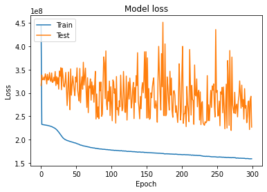

```python
plt.plot(history.history['loss'])
plt.plot(history.history['val_loss'])
plt.title('Model loss')
plt.xlabel('Epoch')
plt.ylabel('Loss')
plt.legend(['Train', 'Test'], loc='upper left')
plt.show()
```

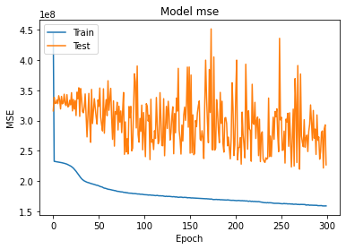

```python
plt.plot(history.history['mse'])
plt.plot(history.history['val_mse'])
plt.title('Model mse')
plt.xlabel('Epoch')
plt.ylabel('MSE')
plt.legend(['Train', 'Test'], loc='upper left')
plt.show()
```

```python
def vis(history, name):
    plt.title(f"{name.upper()}")
    plt.xlabel('epochs')
    plt.ylabel(f"{name.lower()}")
    value = history.history.get(name)
    val_value = history.history.get(f"val_{name}",None)
    epochs = range(1, len(value)+1)
    plt.plot(epochs, value, 'b-',label=f'training{name}')
    if val_value is not None:
        plt.plot(epochs, val_value, 'r:', label=f'validation {name}')
    plt.legend(loc='upper center', bbox_to_anchor=(0.05,1.2), fontsize=10, ncol=1)

def plot_history(history):
    key_value = list(set([i.split('val_')[-1] for i in list(history.history.keys())]))
    plt.figure(figsize=(12,4))
    for idx, key in enumerate(key_value):
        plt.subplot(1, len(key_value), idx+1)
        vis(history, key)
    plt.tight_layout()
    plt.show()
```

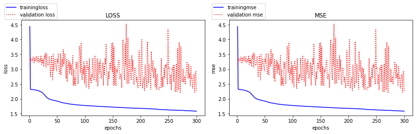

```python
plot_history(history)
```

### 2.3 어떤문제가 발생했는지 설명해주세요.

- 힌트 이전에 lgbm 같은 경우 validation mse가 1.2 ∗ 10 8 이였습니다.

학습이 잘 되고 있지 않는것 같아 보인다.

### 2.4 더 좋은 성능의 딥러닝 모델을 위해

- test set에 대해 딥러닝 모형의 성능을 평가하세요.
- dense 조절, batch_size 조절, regularization, dropout, batch normalization 등의 방법을 활용해 최고의 성능을 얻어보세요.
- 만약 성능의 향상이 어렵다면, 다양한 방법들을 시도하는 것을 목표로 해주세요!

```python
feature_list = list(train_x.columns)

CBE_encoder = CatBoostEncoder()
train_cbe = CBE_encoder.fit_transform(train_x[feature_list], train_y)
test_cbe = CBE_encoder.transform(test_x[feature_list])
```

```python
history = model.fit(train_cbe, train_y, epochs=300, validation_data = (val_cbe, val_y), batch_size = 512)
```

```python
model.evaluate(test_cbe, test_y)
```

```
[3459700480.0, 3459700480.0]
```

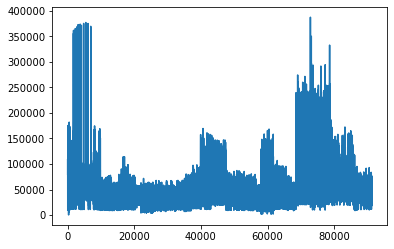

```python
plt.plot(pred_y)
plt.show()
```